# Explor tumor cell classification - SCPCS000490

Ally Hawkins

2024-04-25

## Introduction

This notebook looks at expression of marker genes for tumor cells in a Ewing sarcoma sample, SCPCS000490. Additionally, we see if we can use those marker genes to classify tumor and normal cells using `CellAssign`.

## Setup

```r
suppressMessages(
  # load required packages
  library(SingleCellExperiment),
  library(ggplot2)
)
```

```r
# The base path for the OpenScPCA repository, found by its (hidden) .git directory
repository_base <- rprojroot::find_root(rprojroot::is_git_root)

# The current data directory, found within the repository base directory
data_dir <- file.path(repository_base, "data", "current")
sample_dir <- file.path(data_dir, "SCPCP000015", params$sample_id)

# The path to this module
module_base <- file.path(repository_base, "analyses", "ewings-cell-type")
```

```r
# Input files
sce_filename <- glue::glue("{params$library_id}_processed.rds")
sce_file <- file.path(sample_dir, sce_filename)

marker_genes <- file.path(module_base, "references", "tumor_marker_genes.tsv")

# Output files
tumor_markers_mtx <- file.path(module_base, "references", "tumor_marker_cellassign_mtx.tsv")
```

```r
# read in marker genes table
marker_genes_df <- readr::read_tsv(marker_genes) |>
  # account for genes being from multiple sources
  dplyr::select(cell_type, ensembl_gene_id, gene_symbol) |>
  dplyr::distinct()
```

## Analysis content

### Explore marker gene expression

The first thing we do here is just create a faceted UMAP showing the expression of each marker gene for tumor cells.

```r
# get the gene expression counts for all marker genes
marker_gene_exp <- logcounts(sce[marker_genes, ]) |>
    as.matrix() |>
    t() |>
    as.data.frame() |>
    tibble::rownames_to_column("barcodes")

# pull out the UMAP coordinates and make a data frame to use for plotting
umap_df <- sce |>
  scuttle::makePerCellDF(use.dimred = "UMAP") |>
  # replace UMAP.1 with UMAP1
  dplyr::rename_with(
        \(x) stringr::str_replace(x, "^UMAP\\.", "UMAP"),
        starts_with("UMAP")
      ) |>
  # add in marker gene expression to dataframe
  dplyr::left_join(marker_gene_exp, by = "barcodes") |>
  # combine all genes into a single column for easy faceting
  tidyr::pivot_longer(
    cols = starts_with("ENSG"),
    names_to = "ensembl_gene_id",
    values_to = "gene_expression"
  ) |>
  # join with marker gene df to get gene symbols for plotting
  dplyr::left_join(marker_genes_df, by = c("ensembl_gene_id")) |>
  dplyr::select(barcodes, UMAP1, UMAP2, gene_symbol, ensembl_gene_id, gene_expression, clusters)
```

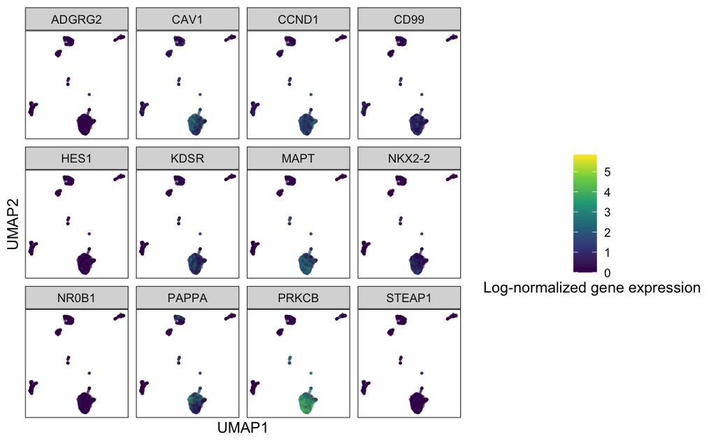

```r
# faceted umap showing a umap panel for each marker gene
ggplot(umap_df, aes(x = UMAP1, y = UMAP2, color = gene_expression)) +
    geom_point(alpha = 0.1, size = 0.4) +
    facet_wrap(vars(gene_symbol)) +
    scale_color_viridis_c() +
    labs(
      color = "Log-normalized gene expression"
    ) +
    # remove axis numbers and background grid
    scale_x_continuous(labels = NULL, breaks = NULL) +
    scale_y_continuous(labels = NULL, breaks = NULL) +
    theme(
      aspect.ratio = 1,
      legend.position = "bottom",
      axis.title = element_text(size = 9, color = "black"),
      strip.text = element_text(size = 8),
      legend.title = element_text(size = 9),
      legend.text = element_text(size = 8)
    ) +
    guides(colour = guide_colorbar(title.position = "bottom", title.hjust = 0.5)) +
  theme_bw()
```

Looking at this plot, there is definitely some variation in the expression of marker genes. It looks like the highest gene expression is seen in the larger group of cells on the bottom right of the UMAP.

Below, we can get the mean gene expression of all marker genes and plot in a single UMAP.

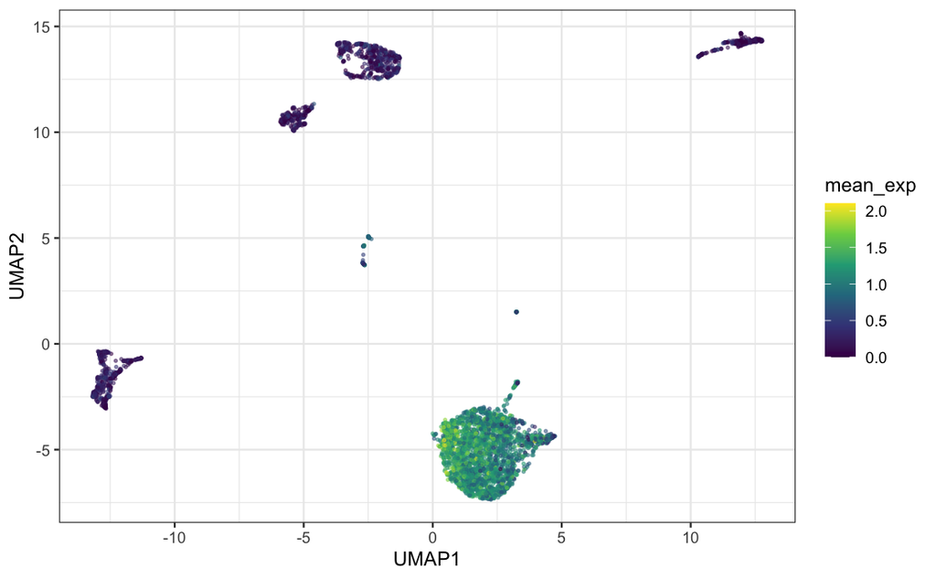

```r
# calculate mean gene expression across all marker genes in list
marker_mean_exp <- umap_df |>
  dplyr::group_by(barcodes) |>
  dplyr::mutate(mean_exp = mean(gene_expression)) |>
  dplyr::select(barcodes, UMAP1, UMAP2, mean_exp) |>
  dplyr::distinct()

# plot mean gene expression
ggplot(marker_mean_exp, aes(x = UMAP1, y = UMAP2, color = mean_exp)) +
  geom_point(size = 0.5, alpha = 0.5) +
  scale_color_viridis_c() +
  theme_bw()
```

Similar to the individual plots, it looks like there is one group of cells on the bottom right that has the highest mean gene expression. We would anticipate that these are most likely to be the tumor cells.

### Clustering

[figure not shown]

```r
# classify cells as tumor/normal
classification_df <- marker_mean_exp |>
  dplyr::mutate(tumor_normal_classification = dplyr::if_else(mean_exp > 0.5, "Tumor", "Normal"))

ggplot(classification_df, aes(x = UMAP1, y = UMAP2, color = tumor_normal_classification)) +
  geom_point(size = 0.5, alpha = 0.5) +
  theme_bw()
```

### Run CellAssign with marker genes

Create marker genes reference

```r
binary_mtx <- marker_genes_df |>
  dplyr::select(cell_type, ensembl_gene_id) |>
  unique() |>
  tidyr::pivot_wider(
    id_cols = ensembl_gene_id,
    names_from = cell_type,
    values_from = cell_type,
    values_fn = length,
    values_fill = 0
  ) |>
  # add a column with no marker genes
  # cell assign will assign cells to "other" when no other cell types are appropriate
  dplyr::mutate(other = 0)

# export matrix
readr::write_tsv(binary_mtx, tumor_markers_mtx_file)
```

Add script for running CellAssign

```r
cellassign_call <- glue::glue("
python scripts/run-cellassign.py \
  --anndata_file '{anndata_file}' \
  --output_predictions '{cellassign_predictions_file}' \
  --reference '{tumor_markers_mtx}'
")

system(cellassign_call)
```

Read in CellAssign marker genes

```r
predictions <- readr::read_tsv(cellassign_predictions_file)

celltype_assignments <- predictions |>
      tidyr::pivot_longer(
        !barcode,
        names_to = "celltype",
        values_to = "prediction"
      ) |>
      dplyr::group_by(barcode) |>
      dplyr::slice_max(prediction, n = 1) |>
      dplyr::ungroup()

table(celltype_assignments$celltype)
```

What if we restrict our list of marker genes based on our dataset? So we want something that has a mean gene expression of 1.

```r
filtered_markers <- rowData(sce) |>
  as.data.frame() |>
  dplyr::filter(gene_symbol %in% marker_genes_df$gene_symbol,
                mean > 1) |>
  dplyr::pull(gene_ids)

filtered_binary_mtx <- binary_mtx |>
  dplyr::filter(ensembl_gene_id %in% filtered_markers)

readr::write_tsv(filtered_binary_mtx, filtered_markers_mtx_file)
```

```r
cellassign_call <- glue::glue("
python scripts/run-cellassign.py --anndata_file '{anndata_file}' --output_predictions '{filtered_predictions_file}' --reference '{filtered_markers_mtx_file}'
")

system(cellassign_call)
```

```r
predictions <- readr::read_tsv(filtered_predictions_file)

celltype_assignments <- predictions |>
      tidyr::pivot_longer(
        !barcode,
        names_to = "celltype",
        values_to = "prediction"
      ) |>
      dplyr::group_by(barcode) |>
      dplyr::slice_max(prediction, n = 1) |>
      dplyr::ungroup()

table(celltype_assignments$celltype)
```

[figure not shown]

## Session Info

```r
# record the versions of the packages used in this analysis and other environment information
sessionInfo()
```